# Driver Behaviour Detection using Deep Learning

## Setup and Environment

```python
import random
import numpy as np
import torch

# fixing seeds so this run is reproducible
SEED = 42
random.seed(SEED)
np.random.seed(SEED)
torch.manual_seed(SEED)
if torch.backends.mps.is_available():
    torch.mps.manual_seed(SEED)
```

### Importing Necessary Libraries

```python
# importing necessary libraries
# core libraries
import os
import numpy as np
import pandas as pd

# image handling
from PIL import Image

# pytorch core
import torch
import torch.nn as nn
import torch.optim as optim
from torch.utils.data import Dataset, DataLoader

# pytorch vision utilities
import torchvision
from torchvision import transforms, models

# splitting data
from sklearn.model_selection import train_test_split

# evaluation metrics
from sklearn.metrics import accuracy_score, precision_score, recall_score, f1_score
from sklearn.metrics import classification_report, confusion_matrix

# visualisation
import matplotlib.pyplot as plt
import seaborn as sns

# webcam interface, used later in stage 8
import cv2

# progress bars
from tqdm import tqdm

# suppress minor warnings for cleaner output
import warnings
warnings.filterwarnings("ignore")

print("All Imports Successful.")
```

```
All Imports Successful.
```

### GPU / MPS Environment Check

```python
print("PyTorch Version:", torch.__version__)
print("mps Available:", torch.backends.mps.is_available())

# m4 macs use mps as the gpu backend instead of cuda
device = torch.device("mps" if torch.backends.mps.is_available() else "CPU")
print("Using Device:", device)
```

```
PyTorch Version: 2.9.1
mps Available: True
Using Device: mps
```

### Verifying Dataset Path

```python
import os

train_dir = "/Users/linux/Desktop/AI Y3 S2/Computer Vision/Coursework/Dataset/train"

print("Classes Found:", sorted(os.listdir(train_dir)))

print("\nImages Per Class:")
total = 0
for class_folder in sorted(os.listdir(train_dir)):
    class_path = os.path.join(train_dir, class_folder)
    if os.path.isdir(class_path):
        count = len(os.listdir(class_path))
        total += count
        print(f"  {class_folder}: {count} Images")

print(f"\nTotal Images: {total}")
```

```
Classes Found: ['c0', 'c1', 'c2', 'c3', 'c4', 'c5', 'c6', 'c7', 'c8', 'c9']

Images Per Class:
  c0: 2489 Images
  c1: 2267 Images
  c2: 2317 Images
  c3: 2346 Images
  c4: 2326 Images
  c5: 2312 Images
  c6: 2325 Images
  c7: 2002 Images
  c8: 1911 Images
  c9: 2129 Images

Total Images: 22424
```

## Data Exploration

### Checking Dataset Folder Contents

```python
import os

dataset_root = "/Users/linux/Desktop/AI Y3 S2/Computer Vision/Coursework/Dataset"

print("Contents of Dataset Folder:")
print(os.listdir(dataset_root))
```

```
Contents of Dataset Folder:
['.DS_Store', 'test', 'train', 'driver_imgs_list.csv', 'dataset.zip']
```

### Verifying Driver Image List

```python
import pandas as pd

csv_path = "/Users/linux/Desktop/AI Y3 S2/Computer Vision/Coursework/Dataset/driver_imgs_list.csv"

driver_df = pd.read_csv(csv_path)

print("Shape:", driver_df.shape)
print("\nFirst Few Rows:")
print(driver_df.head())

print("\nNumber of unique drivers:", driver_df["subject"].nunique())
print("\nImages Per Class:")
print(driver_df["classname"].value_counts().sort_index())
```

```
Shape: (22424, 3)

First Few Rows:
  subject classname            img
0    p002        c0  img_44733.jpg
1    p002        c0  img_72999.jpg
2    p002        c0  img_25094.jpg
3    p002        c0  img_69092.jpg
4    p002        c0  img_92629.jpg

Number of unique drivers: 26

Images Per Class:
classname
c0    2489
c1    2267
c2    2317
c3    2346
c4    2326
c5    2312
c6    2325
c7    2002
c8    1911
c9    2129
Name: count, dtype: int64
```

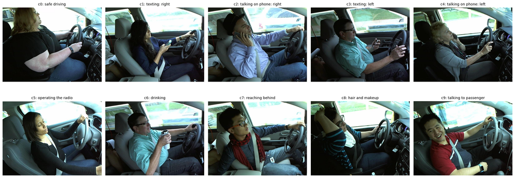

```python
import matplotlib.pyplot as plt
from PIL import Image
import os

train_dir = "/Users/linux/Desktop/AI Y3 S2/Computer Vision/Coursework/Dataset/train"

class_names = {
    "c0": "safe driving",
    "c1": "texting: right",
    "c2": "talking on phone: right",
    "c3": "texting: left",
    "c4": "talking on phone: left",
    "c5": "operating the radio",
    "c6": "drinking",
    "c7": "reaching behind",
    "c8": "hair and makeup",
    "c9": "talking to passenger"
}

fig, axes = plt.subplots(2, 5, figsize=(20, 8))
axes = axes.flatten()

for i, (class_folder, label) in enumerate(class_names.items()):
    class_path = os.path.join(train_dir, class_folder)
    first_image = os.listdir(class_path)[0]
    img_path = os.path.join(class_path, first_image)

    img = Image.open(img_path)
    axes[i].imshow(img)
    axes[i].set_title(f"{class_folder}: {label}", fontsize=10)
    axes[i].axis("off")

plt.tight_layout()
plt.show()
```

### Checking Image Dimensions

```python
from PIL import Image
import os

train_dir = "/Users/linux/Desktop/AI Y3 S2/Computer Vision/Coursework/Dataset/train"

sample_path = os.path.join(train_dir, "c0", os.listdir(os.path.join(train_dir, "c0"))[0])
sample_img = Image.open(sample_path)

print("Sample Image Size:", sample_img.size)
print("Sample Image Mode:", sample_img.mode)
```

```
Sample Image Size: (640, 480)
Sample Image Mode: RGB
```

## Train Validation Test Split

### Splitting Driver Aware data into Train Val Test Split

```python
from sklearn.model_selection import GroupShuffleSplit

# load the driver mapping again for clarity
csv_path = "/Users/linux/Desktop/AI Y3 S2/Computer Vision/Coursework/Dataset/driver_imgs_list.csv"
driver_df = pd.read_csv(csv_path)

# build the full image path for each row
train_dir = "/Users/linux/Desktop/AI Y3 S2/Computer Vision/Coursework/Dataset/train"
driver_df["image_path"] = driver_df.apply(
    lambda row: os.path.join(train_dir, row["classname"], row["img"]), axis=1
)

# first split: 80 percent drivers for train, 20 percent for temp (val + test)
gss1 = GroupShuffleSplit(n_splits=1, test_size=0.2, random_state=42)
train_idx, temp_idx = next(gss1.split(driver_df, groups=driver_df["subject"]))

train_df = driver_df.iloc[train_idx].reset_index(drop=True)
temp_df = driver_df.iloc[temp_idx].reset_index(drop=True)

# second split: split the remaining 20 percent in half, 10 percent val, 10 percent test
gss2 = GroupShuffleSplit(n_splits=1, test_size=0.5, random_state=42)
val_idx, test_idx = next(gss2.split(temp_df, groups=temp_df["subject"]))

val_df = temp_df.iloc[val_idx].reset_index(drop=True)
test_df = temp_df.iloc[test_idx].reset_index(drop=True)

# to confirm no driver overlap between sets
train_drivers = set(train_df["subject"].unique())
val_drivers = set(val_df["subject"].unique())
test_drivers = set(test_df["subject"].unique())

print("Train images:", len(train_df), "| Drivers:", len(train_drivers))
print("Val images:", len(val_df), "| Drivers:", len(val_drivers))
print("Test images:", len(test_df), "| Drivers:", len(test_drivers))

print("\nOverlap check (should all be empty sets):")
print("Train and Val overlap:", train_drivers & val_drivers)
print("Train and Test overlap:", train_drivers & test_drivers)
print("Val and Test overlap:", val_drivers & test_drivers)
```

```
Train images: 17446 | Drivers: 20
Val images: 2243 | Drivers: 3
Test images: 2735 | Drivers: 3

Overlap check (should all be empty sets):
Train and Val overlap: set()
Train and Test overlap: set()
Val and Test overlap: set()
```

## Preprocessing and DataLoaders

### Defining Image Transformations

```python
# imagenet normalization stats since model 3 will use a pretrained resnet
imagenet_mean = [0.485, 0.456, 0.406]
imagenet_std = [0.229, 0.224, 0.225]

# training transform includes light augmentation
# no horizontal flip here, since flipping would turn texting right into texting left
train_transform = transforms.Compose([
    transforms.Resize((224, 224)),
    transforms.RandomRotation(15),
    transforms.ColorJitter(brightness=0.3, contrast=0.3, saturation=0.2),
    transforms.RandomAffine(degrees=0, translate=(0.1, 0.1), scale=(0.9, 1.1)),
    transforms.ToTensor(),
    transforms.Normalize(mean=imagenet_mean, std=imagenet_std),
    transforms.RandomErasing(p=0.3, scale=(0.02, 0.1)),
])

# validation and test transform has no augmentation, just resize and normalize
eval_transform = transforms.Compose([
    transforms.Resize((224, 224)),
    transforms.ToTensor(),
    transforms.Normalize(mean=imagenet_mean, std=imagenet_std)
])

print("Transforms Defined")
```

```
Transforms Defined
```

### Custom Dataset Class

```python
class DriverBehaviorDataset(Dataset):
    def __init__(self, dataframe, transform):
        self.dataframe = dataframe.reset_index(drop=True)
        self.transform = transform

        # merging the original 10 classes down to 4 behaviour groups
        # c0 safe driving  + c9 talking passenger                      -> Safe / Talking
        # c1 texting right + c2 phone right + c3 texting left + c4 phone left -> Using Phone
        # c5 radio         + c6 drinking                               -> Distracted Driving
        # c7 reaching behind + c8 hair makeup                          -> Reaching / Grooming
        self.class_to_idx = {
            "c0": 0, "c9": 0,
            "c1": 1, "c2": 1, "c3": 1, "c4": 1,
            "c5": 2, "c6": 2,
            "c7": 3, "c8": 3,
        }

    def __len__(self):
        return len(self.dataframe)

    def __getitem__(self, idx):
        row = self.dataframe.iloc[idx]
        img_path = row["image_path"]
        label = self.class_to_idx[row["classname"]]

        image = Image.open(img_path).convert("RGB")
        image = self.transform(image)

        return image, label

print("Dataset Class Defined")
```

```
Dataset Class Defined
```

### Creating Datasets and Data Loaders

```python
train_dataset = DriverBehaviorDataset(train_df, train_transform)
val_dataset = DriverBehaviorDataset(val_df, eval_transform)
test_dataset = DriverBehaviorDataset(test_df, eval_transform)

batch_size = 32

train_loader = DataLoader(train_dataset, batch_size=batch_size, shuffle=True, num_workers=0)
val_loader = DataLoader(val_dataset, batch_size=batch_size, shuffle=False, num_workers=0)
test_loader = DataLoader(test_dataset, batch_size=batch_size, shuffle=False, num_workers=0)

print("Train Dataset Size:", len(train_dataset))
print("Val Dataset Size:", len(val_dataset))
print("Test Dataset Size:", len(test_dataset))

# check one batch to confirm shapes are correct
images, labels = next(iter(train_loader))
print("\nBatch Image Shape:", images.shape)
print("Batch Label Shape:", labels.shape)
print("Sample Labels:", labels[:10])
```

```
Train Dataset Size: 17446
Val Dataset Size: 2243
Test Dataset Size: 2735

Batch Image Shape: torch.Size([32, 3, 224, 224])
Batch Label Shape: torch.Size([32])
Sample Labels: tensor([1, 1, 1, 2, 3, 1, 2, 0, 1, 2])
```

## Model 1: The Baseline CNN

### Defining Baseline CNN Architecture

```python
class BaselineCNN(nn.Module):
    def __init__(self, num_classes=4):
        super(BaselineCNN, self).__init__()

        # block 1: 3 input channels (rgb) to 16 feature maps
        self.conv1 = nn.Conv2d(3, 16, kernel_size=3, padding=1)
        self.pool1 = nn.MaxPool2d(2, 2)

        # block 2: 16 to 32 feature maps
        self.conv2 = nn.Conv2d(16, 32, kernel_size=3, padding=1)
        self.pool2 = nn.MaxPool2d(2, 2)

        # block 3: 32 to 64 feature maps
        self.conv3 = nn.Conv2d(32, 64, kernel_size=3, padding=1)
        self.pool3 = nn.MaxPool2d(2, 2)

        self.relu = nn.ReLU()

        # after 3 poolings, 224 becomes 28 (224 / 2 / 2 / 2)
        # flattened size is 64 channels times 28 times 28
        self.fc1 = nn.Linear(64 * 28 * 28, 128)
        self.fc2 = nn.Linear(128, num_classes)

    def forward(self, x):
        x = self.pool1(self.relu(self.conv1(x)))
        x = self.pool2(self.relu(self.conv2(x)))
        x = self.pool3(self.relu(self.conv3(x)))

        x = x.view(x.size(0), -1)  # flatten

        x = self.relu(self.fc1(x))
        x = self.fc2(x)

        return x

print("Baseline CNN Architecture Defined.")
```

```
Baseline CNN Architecture Defined.
```

### Reusable Training Function

```python
def train_model(model, train_loader, val_loader, device, num_epochs=10, lr=0.001):
    model = model.to(device)

    criterion = nn.CrossEntropyLoss()
    optimizer = optim.Adam(model.parameters(), lr=lr)

    history = {"train_loss": [], "val_loss": [], "train_acc": [], "val_acc": []}

    for epoch in range(num_epochs):
        # training phase
        model.train()
        running_loss = 0.0
        correct = 0
        total = 0

        for images, labels in tqdm(train_loader, desc=f"epoch {epoch+1}/{num_epochs} train"):
            images, labels = images.to(device), labels.to(device)

            optimizer.zero_grad()
            outputs = model(images)
            loss = criterion(outputs, labels)
            loss.backward()
            optimizer.step()

            running_loss += loss.item() * images.size(0)
            _, predicted = torch.max(outputs, 1)
            correct += (predicted == labels).sum().item()
            total += labels.size(0)

        train_loss = running_loss / total
        train_acc = correct / total

        # validation phase
        model.eval()
        val_running_loss = 0.0
        val_correct = 0
        val_total = 0

        with torch.no_grad():
            for images, labels in val_loader:
                images, labels = images.to(device), labels.to(device)
                outputs = model(images)
                loss = criterion(outputs, labels)

                val_running_loss += loss.item() * images.size(0)
                _, predicted = torch.max(outputs, 1)
                val_correct += (predicted == labels).sum().item()
                val_total += labels.size(0)

        val_loss = val_running_loss / val_total
        val_acc = val_correct / val_total

        history["train_loss"].append(train_loss)
        history["val_loss"].append(val_loss)
        history["train_acc"].append(train_acc)
        history["val_acc"].append(val_acc)

        print(f"epoch {epoch+1}: train loss {train_loss:.4f}, train acc {train_acc:.4f}, "
              f"val loss {val_loss:.4f}, val acc {val_acc:.4f}")

    return model, history

print("Training Function Defined.")
```

```
Training Function Defined.
```

### Training the Baseline Model

```python
device = torch.device("mps" if torch.backends.mps.is_available() else "cpu")
print("Training On:", device)

baseline_model = BaselineCNN(num_classes=4)

baseline_model, baseline_history = train_model(
    baseline_model, train_loader, val_loader, device,
    num_epochs=5, lr=0.001
)

# save the trained weights so we dont need to retrain later
os.makedirs("models", exist_ok=True)
torch.save(baseline_model.state_dict(), "models/baseline_cnn.pth")
print("Baseline Model Saved.")
```

```
Training On: mps
```

```
epoch 1: train loss 1.0629, train acc 0.5421, val loss 1.6723, val acc 0.5974
```

```
epoch 2: train loss 0.5865, train acc 0.7776, val loss 1.4340, val acc 0.7218
```

```
epoch 3: train loss 0.3870, train acc 0.8621, val loss 2.3065, val acc 0.7379
```

```
epoch 4: train loss 0.2890, train acc 0.9046, val loss 2.6067, val acc 0.7151
```

```
epoch 5: train loss 0.2538, train acc 0.9150, val loss 2.4007, val acc 0.7062
Baseline Model Saved.
```

### Plotting Baseline Training Curves

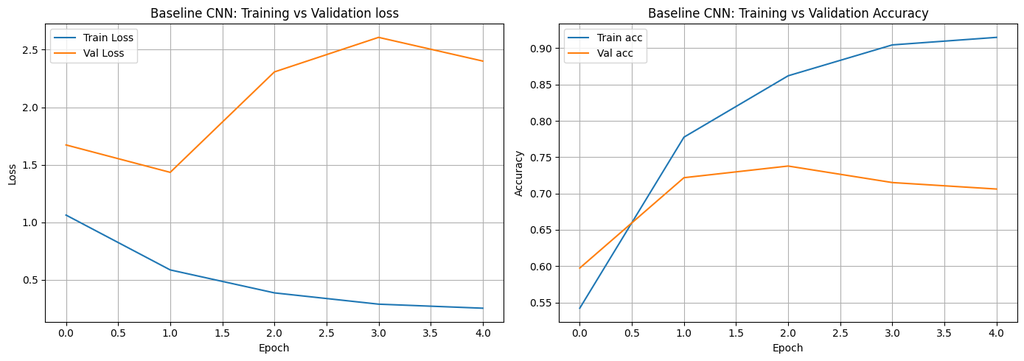

```python
import os
os.makedirs("outputs", exist_ok=True)

fig, axes = plt.subplots(1, 2, figsize=(14, 5))

axes[0].plot(baseline_history["train_loss"], label="Train Loss")
axes[0].plot(baseline_history["val_loss"], label="Val Loss")
axes[0].set_xlabel("Epoch")
axes[0].set_ylabel("Loss")
axes[0].set_title("Baseline CNN: Training vs Validation loss")
axes[0].legend()
axes[0].grid(True)

axes[1].plot(baseline_history["train_acc"], label="Train acc")
axes[1].plot(baseline_history["val_acc"], label="Val acc")
axes[1].set_xlabel("Epoch")
axes[1].set_ylabel("Accuracy")
axes[1].set_title("Baseline CNN: Training vs Validation Accuracy")
axes[1].legend()
axes[1].grid(True)

plt.tight_layout()
plt.savefig("outputs/baseline_training_curves.png")
plt.show()
```

## Model 2: Improved CNN

### Defining Improved CNN Architecture

```python
class ImprovedCNN(nn.Module):
    def __init__(self, num_classes=4, dropout_rate=0.3):
        super(ImprovedCNN, self).__init__()

        # block 1
        self.conv1 = nn.Conv2d(3, 16, kernel_size=3, padding=1)
        self.bn1 = nn.BatchNorm2d(16)
        self.pool1 = nn.MaxPool2d(2, 2)

        # block 2
        self.conv2 = nn.Conv2d(16, 32, kernel_size=3, padding=1)
        self.bn2 = nn.BatchNorm2d(32)
        self.pool2 = nn.MaxPool2d(2, 2)

        # block 3
        self.conv3 = nn.Conv2d(32, 64, kernel_size=3, padding=1)
        self.bn3 = nn.BatchNorm2d(64)
        self.pool3 = nn.MaxPool2d(2, 2)

        self.relu = nn.ReLU()
        self.dropout = nn.Dropout(dropout_rate)

        # after 3 poolings, 224 becomes 28
        self.fc1 = nn.Linear(64 * 28 * 28, 128)
        self.fc2 = nn.Linear(128, num_classes)

    def forward(self, x):
        x = self.pool1(self.relu(self.bn1(self.conv1(x))))
        x = self.pool2(self.relu(self.bn2(self.conv2(x))))
        x = self.pool3(self.relu(self.bn3(self.conv3(x))))

        x = x.view(x.size(0), -1)  # flatten

        x = self.dropout(x)  # dropout before fully connected layers
        x = self.relu(self.fc1(x))
        x = self.dropout(x)  # dropout again before final classification
        x = self.fc2(x)

        return x

print("Improved CNN Architecture Defined.")
```

```
Improved CNN Architecture Defined.
```

### Defining Hyperparameter Configurations

```python
configs = [
    {"name": "config_a", "lr": 0.001, "dropout_rate": 0.3, "optimizer": "adam"},
    {"name": "config_b", "lr": 0.0005, "dropout_rate": 0.5, "optimizer": "adam"},
    {"name": "config_c", "lr": 0.001, "dropout_rate": 0.3, "optimizer": "sgd"},
]

for c in configs:
    print(c)
```

```
{'name': 'config_a', 'lr': 0.001, 'dropout_rate': 0.3, 'optimizer': 'adam'}
{'name': 'config_b', 'lr': 0.0005, 'dropout_rate': 0.5, 'optimizer': 'adam'}
{'name': 'config_c', 'lr': 0.001, 'dropout_rate': 0.3, 'optimizer': 'sgd'}
```

### Updating Training Function with Optimiser Choice

```python
def train_model_v2(model, train_loader, val_loader, device, num_epochs, lr, optimizer_name):
    model = model.to(device)

    criterion = nn.CrossEntropyLoss()

    if optimizer_name == "adam":
        optimizer = optim.Adam(model.parameters(), lr=lr)
    elif optimizer_name == "sgd":
        optimizer = optim.SGD(model.parameters(), lr=lr, momentum=0.9)
    else:
        raise ValueError("unsupported optimizer name")

    history = {"train_loss": [], "val_loss": [], "train_acc": [], "val_acc": []}

    for epoch in range(num_epochs):
        model.train()
        running_loss = 0.0
        correct = 0
        total = 0

        for images, labels in tqdm(train_loader, desc=f"epoch {epoch+1}/{num_epochs} train"):
            images, labels = images.to(device), labels.to(device)

            optimizer.zero_grad()
            outputs = model(images)
            loss = criterion(outputs, labels)
            loss.backward()
            optimizer.step()

            running_loss += loss.item() * images.size(0)
            _, predicted = torch.max(outputs, 1)
            correct += (predicted == labels).sum().item()
            total += labels.size(0)

        train_loss = running_loss / total
        train_acc = correct / total

        model.eval()
        val_running_loss = 0.0
        val_correct = 0
        val_total = 0

        with torch.no_grad():
            for images, labels in val_loader:
                images, labels = images.to(device), labels.to(device)
                outputs = model(images)
                loss = criterion(outputs, labels)

                val_running_loss += loss.item() * images.size(0)
                _, predicted = torch.max(outputs, 1)
                val_correct += (predicted == labels).sum().item()
                val_total += labels.size(0)

        val_loss = val_running_loss / val_total
        val_acc = val_correct / val_total

        history["train_loss"].append(train_loss)
        history["val_loss"].append(val_loss)
        history["train_acc"].append(train_acc)
        history["val_acc"].append(val_acc)

        print(f"epoch {epoch+1}: train loss {train_loss:.4f}, train acc {train_acc:.4f}, "
              f"val loss {val_loss:.4f}, val acc {val_acc:.4f}")

    return model, history

print("Training Function v2 Defined.")
```

```
Training Function v2 Defined.
```

### Training All Three Configurations

```python
results = {}

for config in configs:
    print(f"training {config['name']}: lr={config['lr']}, dropout={config['dropout_rate']}, optimizer={config['optimizer']}")

    model = ImprovedCNN(num_classes=4, dropout_rate=config["dropout_rate"])

    trained_model, history = train_model_v2(
        model, train_loader, val_loader, device,
        num_epochs=5, lr=config["lr"], optimizer_name=config["optimizer"]
    )

    results[config["name"]] = {
        "model": trained_model,
        "history": history,
        "config": config
    }

    # save each config's weights separately
    torch.save(trained_model.state_dict(), f"models/improved_{config['name']}.pth")

print("\nAll configs trained.")
```

```
training config_a: lr=0.001, dropout=0.3, optimizer=adam
```

```
epoch 1: train loss 1.5020, train acc 0.4083, val loss 1.3403, val acc 0.3874
```

```
epoch 2: train loss 1.3225, train acc 0.4135, val loss 1.3394, val acc 0.3874
```

```
epoch 3: train loss 1.3208, train acc 0.4135, val loss 1.3400, val acc 0.3874
```

```
epoch 4: train loss 1.3207, train acc 0.4135, val loss 1.3400, val acc 0.3874
```

```
epoch 5: train loss 1.3207, train acc 0.4135, val loss 1.3404, val acc 0.3874
training config_b: lr=0.0005, dropout=0.5, optimizer=adam
```

```
epoch 1: train loss 1.4354, train acc 0.3762, val loss 1.3199, val acc 0.4289
```

```
epoch 2: train loss 1.3318, train acc 0.4176, val loss 1.3411, val acc 0.3874
```

```
epoch 3: train loss 1.3244, train acc 0.4135, val loss 1.3389, val acc 0.3874
```

```
epoch 4: train loss 1.3214, train acc 0.4135, val loss 1.3393, val acc 0.3874
```

```
epoch 5: train loss 1.3201, train acc 0.4144, val loss 1.3321, val acc 0.3959
training config_c: lr=0.001, dropout=0.3, optimizer=sgd
```

```
epoch 1: train loss 1.2140, train acc 0.4423, val loss 1.7966, val acc 0.4463
```

```
epoch 2: train loss 1.0502, train acc 0.5209, val loss 2.1106, val acc 0.5457
```

```
epoch 3: train loss 0.9798, train acc 0.5581, val loss 2.3780, val acc 0.3990
```

```
epoch 4: train loss 0.9141, train acc 0.5892, val loss 2.8491, val acc 0.5328
```

```
epoch 5: train loss 0.8783, train acc 0.6105, val loss 2.9606, val acc 0.5457

All configs trained.
```

### Comparing all three Configurations

```python
import pandas as pd

comparison_data = []
for name, result in results.items():
    final_epoch = -1
    comparison_data.append({
        "config": name,
        "optimizer": result["config"]["optimizer"],
        "lr": result["config"]["lr"],
        "dropout": result["config"]["dropout_rate"],
        "final_train_acc": result["history"]["train_acc"][final_epoch],
        "final_val_acc": result["history"]["val_acc"][final_epoch],
        "final_val_loss": result["history"]["val_loss"][final_epoch]
    })

comparison_df = pd.DataFrame(comparison_data)
print(comparison_df.to_string(index=False))
```

```
  config optimizer     lr  dropout  final_train_acc  final_val_acc  final_val_loss
config_a      adam 0.0010      0.3         0.413505       0.387428        1.340432
config_b      adam 0.0005      0.5         0.414364       0.395898        1.332109
config_c       sgd 0.0010      0.3         0.610512       0.545698        2.960614
```

### Extend Training on the SGD Config

```python
def train_model_early_stop(model, train_loader, val_loader, device, max_epochs, lr, optimizer_name, patience=3):
    model = model.to(device)
    criterion = nn.CrossEntropyLoss()

    if optimizer_name == "adam":
        optimizer = optim.Adam(model.parameters(), lr=lr)
    elif optimizer_name == "sgd":
        optimizer = optim.SGD(model.parameters(), lr=lr, momentum=0.9)

    history = {"train_loss": [], "val_loss": [], "train_acc": [], "val_acc": []}
    best_val_loss = float("inf")
    epochs_no_improve = 0

    for epoch in range(max_epochs):
        model.train()
        running_loss = 0.0
        correct = 0
        total = 0

        for images, labels in tqdm(train_loader, desc=f"epoch {epoch+1}/{max_epochs} train"):
            images, labels = images.to(device), labels.to(device)
            optimizer.zero_grad()
            outputs = model(images)
            loss = criterion(outputs, labels)
            loss.backward()
            optimizer.step()

            running_loss += loss.item() * images.size(0)
            _, predicted = torch.max(outputs, 1)
            correct += (predicted == labels).sum().item()
            total += labels.size(0)

        train_loss = running_loss / total
        train_acc = correct / total

        model.eval()
        val_running_loss = 0.0
        val_correct = 0
        val_total = 0

        with torch.no_grad():
            for images, labels in val_loader:
                images, labels = images.to(device), labels.to(device)
                outputs = model(images)
                loss = criterion(outputs, labels)

                val_running_loss += loss.item() * images.size(0)
                _, predicted = torch.max(outputs, 1)
                val_correct += (predicted == labels).sum().item()
                val_total += labels.size(0)

        val_loss = val_running_loss / val_total
        val_acc = val_correct / val_total

        history["train_loss"].append(train_loss)
        history["val_loss"].append(val_loss)
        history["train_acc"].append(train_acc)
        history["val_acc"].append(val_acc)

        print(f"epoch {epoch+1}: train loss {train_loss:.4f}, train acc {train_acc:.4f}, "
              f"val loss {val_loss:.4f}, val acc {val_acc:.4f}")

        # early stopping check
        if val_loss < best_val_loss:
            best_val_loss = val_loss
            epochs_no_improve = 0
            torch.save(model.state_dict(), "models/improved_cnn_best.pth")
        else:
            epochs_no_improve += 1
            if epochs_no_improve >= patience:
                print(f"early stopping triggered at epoch {epoch+1}")
                break

    return model, history


# retrain config c with more epochs and early stopping
improved_model = ImprovedCNN(num_classes=4, dropout_rate=0.3)

improved_model, improved_history = train_model_early_stop(
    improved_model, train_loader, val_loader, device,
    max_epochs=15, lr=0.001, optimizer_name="sgd", patience=3
)

print("\nImproved Model Training Complete.")
```

```
epoch 1: train loss 1.2135, train acc 0.4396, val loss 1.8357, val acc 0.4663
```

```
epoch 2: train loss 1.0603, train acc 0.5130, val loss 2.1918, val acc 0.3901
```

```
epoch 3: train loss 0.9658, train acc 0.5644, val loss 2.8348, val acc 0.4726
```

```
epoch 4: train loss 0.8997, train acc 0.5990, val loss 2.6537, val acc 0.5854
early stopping triggered at epoch 4

Improved Model Training Complete.
```

### Attempt 2 at Improved CNN

```python
def train_model_v3(model, train_loader, val_loader, device, max_epochs, lr, optimizer_name, patience, weight_decay=0.0):
    model = model.to(device)
    criterion = nn.CrossEntropyLoss()

    if optimizer_name == "adam":
        optimizer = optim.Adam(model.parameters(), lr=lr, weight_decay=weight_decay)
    elif optimizer_name == "sgd":
        optimizer = optim.SGD(model.parameters(), lr=lr, momentum=0.9, weight_decay=weight_decay)

    history = {"train_loss": [], "val_loss": [], "train_acc": [], "val_acc": []}
    best_val_loss = float("inf")
    epochs_no_improve = 0

    for epoch in range(max_epochs):
        model.train()
        running_loss = 0.0
        correct = 0
        total = 0

        for images, labels in tqdm(train_loader, desc=f"epoch {epoch+1}/{max_epochs} train"):
            images, labels = images.to(device), labels.to(device)
            optimizer.zero_grad()
            outputs = model(images)
            loss = criterion(outputs, labels)
            loss.backward()
            optimizer.step()

            running_loss += loss.item() * images.size(0)
            _, predicted = torch.max(outputs, 1)
            correct += (predicted == labels).sum().item()
            total += labels.size(0)

        train_loss = running_loss / total
        train_acc = correct / total

        model.eval()
        val_running_loss = 0.0
        val_correct = 0
        val_total = 0

        with torch.no_grad():
            for images, labels in val_loader:
                images, labels = images.to(device), labels.to(device)
                outputs = model(images)
                loss = criterion(outputs, labels)

                val_running_loss += loss.item() * images.size(0)
                _, predicted = torch.max(outputs, 1)
                val_correct += (predicted == labels).sum().item()
                val_total += labels.size(0)

        val_loss = val_running_loss / val_total
        val_acc = val_correct / val_total

        history["train_loss"].append(train_loss)
        history["val_loss"].append(val_loss)
        history["train_acc"].append(train_acc)
        history["val_acc"].append(val_acc)

        print(f"epoch {epoch+1}: train loss {train_loss:.4f}, train acc {train_acc:.4f}, "
              f"val loss {val_loss:.4f}, val acc {val_acc:.4f}")

        if val_loss < best_val_loss:
            best_val_loss = val_loss
            epochs_no_improve = 0
            torch.save(model.state_dict(), "models/improved_cnn_v2_best.pth")
            print(f"  -> new best model saved")
        else:
            epochs_no_improve += 1
            if epochs_no_improve >= patience:
                print(f"early stopping triggered at epoch {epoch+1}")
                break

    return model, history


# attempt 2: lower lr, weight decay, more patience
improved_model_v2 = ImprovedCNN(num_classes=4, dropout_rate=0.3)

improved_model_v2, improved_history_v2 = train_model_v3(
    improved_model_v2, train_loader, val_loader, device,
    max_epochs=20, lr=0.0005, optimizer_name="sgd", patience=5, weight_decay=1e-4
)

print("\nImproved Model v2 Training Complete.")
```

```
epoch 1: train loss 1.2000, train acc 0.4578, val loss 1.3672, val acc 0.5448
  -> new best model saved
```

```
epoch 2: train loss 1.0162, train acc 0.5480, val loss 1.7393, val acc 0.5216
```

```
epoch 3: train loss 0.9144, train acc 0.6005, val loss 2.0639, val acc 0.5386
```

```
epoch 4: train loss 0.8289, train acc 0.6468, val loss 2.5760, val acc 0.5943
```

```
epoch 5: train loss 0.7722, train acc 0.6760, val loss 2.3595, val acc 0.6460
```

```
epoch 6: train loss 0.7022, train acc 0.7103, val loss 3.7855, val acc 0.5484
early stopping triggered at epoch 6

Improved Model v2 Training Complete.
```

### Attempt 3 at Improved CNN by Fixing the Architecture

```python
class ImprovedCNNv2(nn.Module):
    def __init__(self, num_classes=4, dropout_rate=0.3):
        super(ImprovedCNNv2, self).__init__()

        self.conv1 = nn.Conv2d(3, 16, kernel_size=3, padding=1)
        self.bn1 = nn.BatchNorm2d(16)
        self.pool1 = nn.MaxPool2d(2, 2)

        self.conv2 = nn.Conv2d(16, 32, kernel_size=3, padding=1)
        self.bn2 = nn.BatchNorm2d(32)
        self.pool2 = nn.MaxPool2d(2, 2)

        self.conv3 = nn.Conv2d(32, 64, kernel_size=3, padding=1)
        self.bn3 = nn.BatchNorm2d(64)
        self.pool3 = nn.MaxPool2d(2, 2)

        # added fourth block for more depth
        self.conv4 = nn.Conv2d(64, 128, kernel_size=3, padding=1)
        self.bn4 = nn.BatchNorm2d(128)
        self.pool4 = nn.MaxPool2d(2, 2)

        self.relu = nn.ReLU()
        self.dropout = nn.Dropout(dropout_rate)

        # global average pooling collapses each channel to a single value
        # this replaces the huge flatten + dense layer, cutting parameters drastically
        self.gap = nn.AdaptiveAvgPool2d(1)

        # fc layer now only takes 128 inputs instead of 50176
        self.fc = nn.Linear(128, num_classes)

    def forward(self, x):
        x = self.pool1(self.relu(self.bn1(self.conv1(x))))
        x = self.pool2(self.relu(self.bn2(self.conv2(x))))
        x = self.pool3(self.relu(self.bn3(self.conv3(x))))
        x = self.pool4(self.relu(self.bn4(self.conv4(x))))

        x = self.gap(x)  # shape becomes (batch, 128, 1, 1)
        x = x.view(x.size(0), -1)  # flatten to (batch, 128)

        x = self.dropout(x)
        x = self.fc(x)

        return x

print("Improved CNN v2 Architecture Defined.")

# quick parameter count comparison
old_model = ImprovedCNN(num_classes=4)
new_model = ImprovedCNNv2(num_classes=4)

old_params = sum(p.numel() for p in old_model.parameters())
new_params = sum(p.numel() for p in new_model.parameters())

print(f"\nOld Architecture Parameters: {old_params:,}")
print(f"New Architecture Parameters: {new_params:,}")
print(f"Reduction: {(1 - new_params/old_params)*100:.1f}%")
```

```
Improved CNN v2 Architecture Defined.

Old Architecture Parameters: 6,446,980
New Architecture Parameters: 98,436
Reduction: 98.5%
```

### Training the Fixed Architecture

```python
improved_model_v3 = ImprovedCNNv2(num_classes=4, dropout_rate=0.3)

improved_model_v3, improved_history_v3 = train_model_v3(
    improved_model_v3, train_loader, val_loader, device,
    max_epochs=20, lr=0.0005, optimizer_name="sgd", patience=5, weight_decay=1e-4
)

print("\nImproved Model v3 Training Complete.")
```

```
epoch 1: train loss 1.3394, train acc 0.3961, val loss 1.3324, val acc 0.3874
  -> new best model saved
```

```
epoch 2: train loss 1.3194, train acc 0.4107, val loss 1.3444, val acc 0.4151
```

```
epoch 3: train loss 1.3029, train acc 0.4117, val loss 1.3282, val acc 0.3986
  -> new best model saved
```

```
epoch 4: train loss 1.2841, train acc 0.4157, val loss 1.3084, val acc 0.3968
  -> new best model saved
```

```
epoch 5: train loss 1.2640, train acc 0.4243, val loss 1.2938, val acc 0.3883
  -> new best model saved
```

```
epoch 6: train loss 1.2384, train acc 0.4293, val loss 1.2664, val acc 0.4204
  -> new best model saved
```

```
epoch 7: train loss 1.2116, train acc 0.4399, val loss 1.2938, val acc 0.3794
```

```
epoch 8: train loss 1.1855, train acc 0.4582, val loss 1.2415, val acc 0.4293
  -> new best model saved
```

```
epoch 9: train loss 1.1604, train acc 0.4712, val loss 1.2773, val acc 0.3999
```

```
epoch 10: train loss 1.1419, train acc 0.4785, val loss 1.2965, val acc 0.4311
```

```
epoch 11: train loss 1.1288, train acc 0.4903, val loss 1.4292, val acc 0.4097
```

```
epoch 12: train loss 1.1088, train acc 0.5050, val loss 1.6755, val acc 0.3482
```

```
epoch 13: train loss 1.0900, train acc 0.5111, val loss 1.5792, val acc 0.3981
early stopping triggered at epoch 13

Improved Model v3 Training Complete.
```

### Attempt 4 at Improved CNN

```python
improved_model_v4 = ImprovedCNNv2(num_classes=4, dropout_rate=0.2)

improved_model_v4, improved_history_v4 = train_model_v3(
    improved_model_v4, train_loader, val_loader, device,
    max_epochs=20, lr=0.01, optimizer_name="sgd", patience=5, weight_decay=1e-5
)

print("\nImproved Model v4 Training Complete.")
```

```
epoch 1: train loss 1.2782, train acc 0.4129, val loss 1.6804, val acc 0.2782
  -> new best model saved
```

```
epoch 2: train loss 1.1525, train acc 0.4772, val loss 1.3924, val acc 0.3370
  -> new best model saved
```

```
epoch 3: train loss 1.0586, train acc 0.5383, val loss 1.7613, val acc 0.4182
```

```
epoch 4: train loss 0.9304, train acc 0.6125, val loss 2.5383, val acc 0.3848
```

```
epoch 5: train loss 0.8076, train acc 0.6854, val loss 2.6095, val acc 0.5876
```

```
epoch 6: train loss 0.6745, train acc 0.7508, val loss 6.7265, val acc 0.2390
```

```
epoch 7: train loss 0.5672, train acc 0.7949, val loss 5.2881, val acc 0.3656
early stopping triggered at epoch 7

Improved Model v4 Training Complete.
```

### Adding class weight computation

```python
# the merge left "using phone" holding four of the original classes so it dominates training
# inverse frequency weights stop the model collapsing onto the majority class
merge_map = {"c0": 0, "c9": 0, "c1": 1, "c2": 1, "c3": 1, "c4": 1,
             "c5": 2, "c6": 2, "c7": 3, "c8": 3}

train_counts = train_df["classname"].map(merge_map).value_counts().sort_index()

class_weights = torch.tensor(
    [len(train_df) / (4 * train_counts[i]) for i in range(4)],
    dtype=torch.float32
).to(device)

group_labels = ["Safe / Talking", "Using Phone", "Distracted Driving", "Reaching / Grooming"]

for i in range(4):
    pct = train_counts[i] / len(train_df) * 100
    print(f"{group_labels[i]:22s} {train_counts[i]:6d}  ({pct:.1f}%)  weight={class_weights[i]:.3f}")
```

```
Safe / Talking           3618  (20.7%)  weight=1.206
Using Phone              7214  (41.4%)  weight=0.605
Distracted Driving       3581  (20.5%)  weight=1.218
Reaching / Grooming      3033  (17.4%)  weight=1.438
```

```python
from sklearn.metrics import f1_score

def val_macro_f1(model, val_loader, device):
    model.eval()
    preds, labels = [], []
    with torch.no_grad():
        for images, lbls in val_loader:
            images = images.to(device)
            out = model(images)
            _, p = torch.max(out, 1)
            preds.extend(p.cpu().numpy())
            labels.extend(lbls.numpy())
    return f1_score(labels, preds, average="macro")
```

```python
def train_model_v5(model, train_loader, val_loader, device, max_epochs, lr,
                   optimizer_name, patience, weight_decay=0.0,
                   class_weights=None, min_epoch=3,
                   label_smoothing=0.0,
                   save_path="models/improved_cnn_final.pth"):
    model = model.to(device)

    # weighted loss so the minority classes are not ignored after the merge
    # label smoothing stops the model becoming over-confident on training drivers
    criterion = nn.CrossEntropyLoss(weight=class_weights, label_smoothing=label_smoothing)

    if optimizer_name == "adam":
        optimizer = optim.Adam(model.parameters(), lr=lr, weight_decay=weight_decay)
    elif optimizer_name == "sgd":
        optimizer = optim.SGD(model.parameters(), lr=lr, momentum=0.9, weight_decay=weight_decay)

    # sgd at a fixed lr of 0.01 made validation accuracy oscillate badly
    # cosine annealing decays the lr so the model settles instead of bouncing
    scheduler = optim.lr_scheduler.CosineAnnealingLR(optimizer, T_max=max_epochs)

    history = {"train_loss": [], "val_loss": [], "train_acc": [], "val_acc": []}
    best_val_acc = 0.0
    best_val_f1 = 0.0
    epochs_no_improve = 0

    for epoch in range(max_epochs):
        model.train()
        running_loss = 0.0
        correct = 0
        total = 0

        for images, labels in tqdm(train_loader, desc=f"epoch {epoch+1}/{max_epochs} train"):
            images, labels = images.to(device), labels.to(device)
            optimizer.zero_grad()
            outputs = model(images)
            loss = criterion(outputs, labels)
            loss.backward()
            optimizer.step()

            running_loss += loss.item() * images.size(0)
            _, predicted = torch.max(outputs, 1)
            correct += (predicted == labels).sum().item()
            total += labels.size(0)

        train_loss = running_loss / total
        train_acc = correct / total

        model.eval()
        val_running_loss = 0.0
        val_correct = 0
        val_total = 0

        with torch.no_grad():
            for images, labels in val_loader:
                images, labels = images.to(device), labels.to(device)
                outputs = model(images)
                loss = criterion(outputs, labels)

                val_running_loss += loss.item() * images.size(0)
                _, predicted = torch.max(outputs, 1)
                val_correct += (predicted == labels).sum().item()
                val_total += labels.size(0)

        val_loss = val_running_loss / val_total
        val_acc = val_correct / val_total

        history["train_loss"].append(train_loss)
        history["val_loss"].append(val_loss)
        history["train_acc"].append(train_acc)
        history["val_acc"].append(val_acc)

        scheduler.step()

        print(f"epoch {epoch+1}: train loss {train_loss:.4f}, train acc {train_acc:.4f}, "
              f"val loss {val_loss:.4f}, val acc {val_acc:.4f}, lr {scheduler.get_last_lr()[0]:.5f}")

        # checkpoint on macro f1, not raw accuracy
        # raw accuracy let the model win an epoch where one class was dead
        # macro f1 only rewards epochs where all four classes are alive
        if epoch + 1 < min_epoch:
            print("  -> warmup, not eligible for checkpoint yet")
            continue

        current_f1 = val_macro_f1(model, val_loader, device)

        if current_f1 > best_val_f1:
            best_val_f1 = current_f1
            epochs_no_improve = 0
            torch.save(model.state_dict(), save_path)
            print(f"  -> new best model saved (macro_f1={current_f1:.4f}, val_acc={val_acc:.4f}, epoch {epoch+1})")
        else:
            epochs_no_improve += 1
            if epochs_no_improve >= patience:
                print(f"early stopping triggered at epoch {epoch+1}")
                break

    return model, history

print("Training function v5 defined: weighted loss, cosine annealing, warmup checkpointing.")
```

```
Training function v5 defined: weighted loss, cosine annealing, warmup checkpointing.
```

### Retraining with Corrected Checkpointing

```python
improved_model_final = ImprovedCNNv2(num_classes=4, dropout_rate=0.5)

improved_model_final, improved_history_final = train_model_v5(
    improved_model_final, train_loader, val_loader, device,
    max_epochs=30, lr=0.003, optimizer_name="sgd", patience=10,
    weight_decay=1e-3, class_weights=class_weights, min_epoch=5
)

best_epoch = improved_history_final["val_acc"].index(max(improved_history_final["val_acc"])) + 1
print("\nFinal Improved Model Training Complete.")
print(f"Best Validation Accuracy: {max(improved_history_final['val_acc']):.4f} at epoch {best_epoch}")
```

```
epoch 1: train loss 1.3906, train acc 0.2787, val loss 1.3826, val acc 0.2675, lr 0.00299
  -> warmup, not eligible for checkpoint yet
```

```
epoch 2: train loss 1.3068, train acc 0.3318, val loss 1.3139, val acc 0.4200, lr 0.00297
  -> warmup, not eligible for checkpoint yet
```

```
epoch 3: train loss 1.2373, train acc 0.3738, val loss 1.4316, val acc 0.3718, lr 0.00293
  -> warmup, not eligible for checkpoint yet
```

```
epoch 4: train loss 1.1950, train acc 0.4051, val loss 1.4105, val acc 0.3393, lr 0.00287
  -> warmup, not eligible for checkpoint yet
```

```
epoch 5: train loss 1.1531, train acc 0.4254, val loss 1.5900, val acc 0.3370, lr 0.00280
  -> new best model saved (macro_f1=0.3065, val_acc=0.3370, epoch 5)
```

```
epoch 6: train loss 1.1205, train acc 0.4498, val loss 1.6177, val acc 0.4333, lr 0.00271
  -> new best model saved (macro_f1=0.4287, val_acc=0.4333, epoch 6)
```

```
epoch 7: train loss 1.0859, train acc 0.4690, val loss 1.4255, val acc 0.3696, lr 0.00261
```

```
epoch 8: train loss 1.0351, train acc 0.4980, val loss 2.0745, val acc 0.4695, lr 0.00250
  -> new best model saved (macro_f1=0.4439, val_acc=0.4695, epoch 8)
```

```
epoch 9: train loss 1.0087, train acc 0.5136, val loss 3.2254, val acc 0.2666, lr 0.00238
```

```
epoch 10: train loss 0.9556, train acc 0.5461, val loss 1.7404, val acc 0.2782, lr 0.00225
```

```
epoch 11: train loss 0.9215, train acc 0.5675, val loss 2.5503, val acc 0.3995, lr 0.00211
```

```
epoch 12: train loss 0.8830, train acc 0.5883, val loss 2.9690, val acc 0.3696, lr 0.00196
```

```
epoch 13: train loss 0.8344, train acc 0.6176, val loss 2.1116, val acc 0.4864, lr 0.00181
  -> new best model saved (macro_f1=0.4955, val_acc=0.4864, epoch 13)
```

```
epoch 14: train loss 0.7837, train acc 0.6485, val loss 2.9507, val acc 0.3611, lr 0.00166
```

```
epoch 15: train loss 0.7520, train acc 0.6677, val loss 2.9468, val acc 0.4115, lr 0.00150
```

```
epoch 16: train loss 0.6948, train acc 0.7009, val loss 4.3369, val acc 0.2506, lr 0.00134
```

```
epoch 17: train loss 0.6702, train acc 0.7188, val loss 2.9352, val acc 0.4784, lr 0.00119
```

```
epoch 18: train loss 0.6227, train acc 0.7441, val loss 2.1151, val acc 0.5894, lr 0.00104
  -> new best model saved (macro_f1=0.5896, val_acc=0.5894, epoch 18)
```

```
epoch 19: train loss 0.5850, train acc 0.7610, val loss 2.2476, val acc 0.5510, lr 0.00089
```

```
epoch 20: train loss 0.5601, train acc 0.7765, val loss 2.9376, val acc 0.4253, lr 0.00075
```

```
epoch 21: train loss 0.5341, train acc 0.7903, val loss 1.8343, val acc 0.6045, lr 0.00062
  -> new best model saved (macro_f1=0.6074, val_acc=0.6045, epoch 21)
```

```
epoch 22: train loss 0.5115, train acc 0.7977, val loss 2.0078, val acc 0.6001, lr 0.00050
```

```
epoch 23: train loss 0.4880, train acc 0.8114, val loss 1.8711, val acc 0.5845, lr 0.00039
```

```
epoch 24: train loss 0.4710, train acc 0.8231, val loss 1.9141, val acc 0.5863, lr 0.00029
```

```
epoch 25: train loss 0.4565, train acc 0.8276, val loss 1.8392, val acc 0.6059, lr 0.00020
```

```
epoch 26: train loss 0.4496, train acc 0.8361, val loss 2.0535, val acc 0.5711, lr 0.00013
```

```
epoch 27: train loss 0.4340, train acc 0.8392, val loss 1.8037, val acc 0.5970, lr 0.00007
```

```
epoch 28: train loss 0.4259, train acc 0.8448, val loss 1.8198, val acc 0.5649, lr 0.00003
```

```
epoch 29: train loss 0.4229, train acc 0.8452, val loss 1.7682, val acc 0.5974, lr 0.00001
```

```
epoch 30: train loss 0.4131, train acc 0.8497, val loss 1.6304, val acc 0.6086, lr 0.00000

Final Improved Model Training Complete.
Best Validation Accuracy: 0.6086 at epoch 30
```

### Plotting Best Improved CNN Curves

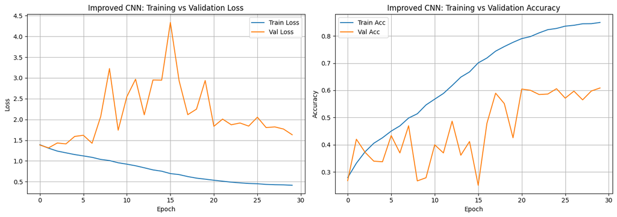

```
Best Validation Accuracy: 0.6086
Best Train Accuracy: 0.8497
```

```python
fig, axes = plt.subplots(1, 2, figsize=(14, 5))

axes[0].plot(improved_history_final["train_loss"], label="Train Loss")
axes[0].plot(improved_history_final["val_loss"], label="Val Loss")
axes[0].set_xlabel("Epoch")
axes[0].set_ylabel("Loss")
axes[0].set_title("Improved CNN: Training vs Validation Loss")
axes[0].legend()
axes[0].grid(True)

axes[1].plot(improved_history_final["train_acc"], label="Train Acc")
axes[1].plot(improved_history_final["val_acc"], label="Val Acc")
axes[1].set_xlabel("Epoch")
axes[1].set_ylabel("Accuracy")
axes[1].set_title("Improved CNN: Training vs Validation Accuracy")
axes[1].legend()
axes[1].grid(True)

plt.tight_layout()
plt.savefig("outputs/improved_training_curves.png")
plt.show()

print(f"Best Validation Accuracy: {max(improved_history_final['val_acc']):.4f}")
print(f"Best Train Accuracy: {max(improved_history_final['train_acc']):.4f}")
```

### Improved CNN v3: Increasing Network Depth

Rather than regularise further, this version tests whether the model was simply too shallow to represent the differences between the four behaviour groups. v3 uses nine convolutional layers arranged as two 3x3 convolutions per block for the first four blocks. Stacking two small convolutions covers the same receptive field as a single larger kernel while using fewer parameters and adding an extra non linearity between them.

Channel widths were kept deliberately modest so that the added depth did not simply supply more capacity for memorisation. Label smoothing of 0.1 was also introduced, which discourages the network from becoming overly confident on the training set. All other settings, including the optimiser, learning rate, dropout rate, weight decay and class weights, were held identical to v2 so that the effect of depth could be isolated.

### Adding the deeper architecture

```python
class ImprovedCNNv3(nn.Module):
    """
    Deeper version of ImprovedCNNv2.

    v2 used four convolutional layers. v3 uses nine, arranged as two 3x3
    convolutions per block for the first four blocks. Stacking two small
    convolutions gives the same receptive field as one larger kernel but
    with fewer parameters and an extra non-linearity in between.

    Channel widths are kept deliberately modest so that adding depth does
    not simply hand the network more capacity to memorise training drivers,
    which was the failure mode observed in v2.
    """
    def __init__(self, num_classes=4, dropout_rate=0.5):
        super(ImprovedCNNv3, self).__init__()

        def block(in_ch, out_ch, double=True):
            layers = [
                nn.Conv2d(in_ch, out_ch, kernel_size=3, padding=1),
                nn.BatchNorm2d(out_ch),
                nn.ReLU(inplace=True),
            ]
            if double:
                layers += [
                    nn.Conv2d(out_ch, out_ch, kernel_size=3, padding=1),
                    nn.BatchNorm2d(out_ch),
                    nn.ReLU(inplace=True),
                ]
            layers.append(nn.MaxPool2d(2, 2))
            return nn.Sequential(*layers)

        self.block1 = block(3, 16)      # 224 -> 112
        self.block2 = block(16, 32)     # 112 -> 56
        self.block3 = block(32, 64)     # 56  -> 28
        self.block4 = block(64, 96)     # 28  -> 14
        self.block5 = block(96, 128, double=False)  # 14 -> 7

        self.gap = nn.AdaptiveAvgPool2d(1)
        self.dropout = nn.Dropout(dropout_rate)
        self.fc = nn.Linear(128, num_classes)

    def forward(self, x):
        x = self.block1(x)
        x = self.block2(x)
        x = self.block3(x)
        x = self.block4(x)
        x = self.block5(x)

        x = self.gap(x)
        x = x.view(x.size(0), -1)
        x = self.dropout(x)
        x = self.fc(x)
        return x


print("Improved CNN v3 Architecture Defined.")

v2_params = sum(p.numel() for p in ImprovedCNNv2(num_classes=4).parameters())
v3_params = sum(p.numel() for p in ImprovedCNNv3(num_classes=4).parameters())

print(f"\nv2 (4 conv layers): {v2_params:,} parameters")
print(f"v3 (9 conv layers): {v3_params:,} parameters")
print(f"Increase: {v3_params/v2_params:.1f}x")
```

```
Improved CNN v3 Architecture Defined.

v2 (4 conv layers): 98,436 parameters
v3 (9 conv layers): 322,836 parameters
Increase: 3.3x
```

```python
improved_model_v3 = ImprovedCNNv3(num_classes=4, dropout_rate=0.5)

improved_model_v3, improved_history_v3 = train_model_v5(
    improved_model_v3, train_loader, val_loader, device,
    max_epochs=25, lr=0.003, optimizer_name="sgd", patience=10,
    weight_decay=1e-3, class_weights=class_weights, min_epoch=5,
    label_smoothing=0.1,
    save_path="models/improved_cnn_v3.pth"
)

best_epoch_v3 = improved_history_v3["val_acc"].index(max(improved_history_v3["val_acc"])) + 1
print("\nImproved CNN v3 Training Complete.")
print(f"Best Validation Accuracy: {max(improved_history_v3['val_acc']):.4f} at epoch {best_epoch_v3}")
```

```
epoch 1: train loss 1.3251, train acc 0.3429, val loss 1.8754, val acc 0.1846, lr 0.00299
  -> warmup, not eligible for checkpoint yet
```

```
epoch 2: train loss 1.0470, train acc 0.5656, val loss 1.1667, val acc 0.5546, lr 0.00295
  -> warmup, not eligible for checkpoint yet
```

```
epoch 3: train loss 0.8153, train acc 0.7599, val loss 1.4956, val acc 0.5042, lr 0.00289
  -> warmup, not eligible for checkpoint yet
```

```
epoch 4: train loss 0.6794, train acc 0.8593, val loss 2.0612, val acc 0.4837, lr 0.00281
  -> warmup, not eligible for checkpoint yet
```

```
epoch 5: train loss 0.6168, train acc 0.8997, val loss 1.0327, val acc 0.7156, lr 0.00271
  -> new best model saved (macro_f1=0.6828, val_acc=0.7156, epoch 5)
```

```
epoch 6: train loss 0.5913, train acc 0.9149, val loss 2.0273, val acc 0.4641, lr 0.00259
```

```
epoch 7: train loss 0.5580, train acc 0.9368, val loss 1.9560, val acc 0.4454, lr 0.00246
```

```
epoch 8: train loss 0.5414, train acc 0.9473, val loss 1.4722, val acc 0.5747, lr 0.00230
```

```
epoch 9: train loss 0.5277, train acc 0.9533, val loss 1.3095, val acc 0.5212, lr 0.00214
```

```
epoch 10: train loss 0.5146, train acc 0.9611, val loss 1.0133, val acc 0.7111, lr 0.00196
  -> new best model saved (macro_f1=0.6848, val_acc=0.7111, epoch 10)
```

```
epoch 11: train loss 0.5064, train acc 0.9650, val loss 1.1500, val acc 0.6514, lr 0.00178
```

```
epoch 12: train loss 0.4953, train acc 0.9703, val loss 2.3799, val acc 0.4079, lr 0.00159
```

```
epoch 13: train loss 0.4893, train acc 0.9745, val loss 1.2604, val acc 0.5912, lr 0.00141
```

```
epoch 14: train loss 0.4833, train acc 0.9765, val loss 0.7663, val acc 0.7931, lr 0.00122
  -> new best model saved (macro_f1=0.7884, val_acc=0.7931, epoch 14)
```

```
epoch 15: train loss 0.4779, train acc 0.9797, val loss 1.1749, val acc 0.5479, lr 0.00104
```

```
epoch 16: train loss 0.4741, train acc 0.9802, val loss 1.0155, val acc 0.6170, lr 0.00086
```

```
epoch 17: train loss 0.4728, train acc 0.9823, val loss 1.0097, val acc 0.6112, lr 0.00070
```

```
epoch 18: train loss 0.4707, train acc 0.9814, val loss 0.8378, val acc 0.7757, lr 0.00054
```

```
epoch 19: train loss 0.4635, train acc 0.9858, val loss 0.9810, val acc 0.6567, lr 0.00041
```

```
epoch 20: train loss 0.4637, train acc 0.9862, val loss 0.8037, val acc 0.7771, lr 0.00029
```

```
epoch 21: train loss 0.4608, train acc 0.9873, val loss 0.8221, val acc 0.7490, lr 0.00019
```

```
epoch 22: train loss 0.4604, train acc 0.9881, val loss 0.8612, val acc 0.7272, lr 0.00011
```

```
epoch 23: train loss 0.4609, train acc 0.9864, val loss 0.8187, val acc 0.7508, lr 0.00005
```

```
epoch 24: train loss 0.4572, train acc 0.9890, val loss 0.8142, val acc 0.7561, lr 0.00001
early stopping triggered at epoch 24

Improved CNN v3 Training Complete.
Best Validation Accuracy: 0.7931 at epoch 14
```

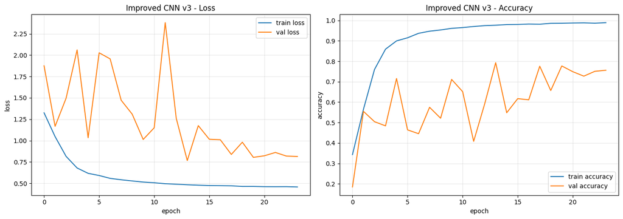

```
v3 training curves saved to outputs/improved_cnn_v3_training_curves.png
```

```python
fig, axes = plt.subplots(1, 2, figsize=(14, 5))

axes[0].plot(improved_history_v3["train_loss"], label="train loss")
axes[0].plot(improved_history_v3["val_loss"], label="val loss")
axes[0].set_xlabel("epoch")
axes[0].set_ylabel("loss")
axes[0].set_title("Improved CNN v3 - Loss")
axes[0].legend()
axes[0].grid(alpha=0.3)

axes[1].plot(improved_history_v3["train_acc"], label="train accuracy")
axes[1].plot(improved_history_v3["val_acc"], label="val accuracy")
axes[1].set_xlabel("epoch")
axes[1].set_ylabel("accuracy")
axes[1].set_title("Improved CNN v3 - Accuracy")
axes[1].legend()
axes[1].grid(alpha=0.3)

plt.tight_layout()
plt.savefig("outputs/improved_cnn_v3_training_curves.png", dpi=120)
plt.show()

print("v3 training curves saved to outputs/improved_cnn_v3_training_curves.png")
```

## Model 3 - Fine-Tuning Pretrained CNN (ResNet18)

### Loading Pretrained ResNet18 and Modifying for 10 Classes

```python
# loading resnet18 pretrained on imagenet
# replacing the final fully connected layer with one that outputs 10 classes
resnet_model = models.resnet18(weights=models.ResNet18_Weights.IMAGENET1K_V1)

# freezing all layers initially, only training the new classification head first
for param in resnet_model.parameters():
    param.requires_grad = False

# replacing the final fc layer as the original resnet18 fc outputs 1000 classes (imagenet)
# we replace it with one that outputs 10 classes (our driver behaviour classes)
num_features = resnet_model.fc.in_features
resnet_model.fc = nn.Linear(num_features, 10)

print("ResNet18 loaded with pretrained imagenet weights.")
print(f"Final FC Layer: {num_features} Inputs -> 10 outputs")

# confirming only the new fc layer is trainable at this stage
trainable_params = sum(p.numel() for p in resnet_model.parameters() if p.requires_grad)
total_params = sum(p.numel() for p in resnet_model.parameters())
print(f"\nTrainable Parameters: {trainable_params:,} / {total_params:,}")
```

```
ResNet18 loaded with pretrained imagenet weights.
Final FC Layer: 512 Inputs -> 10 outputs

Trainable Parameters: 5,130 / 11,181,642
```

### Phase 1: Training Classification Head Only (with 5 epochs)

```python
device = torch.device("mps" if torch.backends.mps.is_available() else "cpu")

resnet_model = resnet_model.to(device)
criterion = nn.CrossEntropyLoss()

# phase 1: only training the new fc head, with backbone frozen
optimizer_phase1 = optim.Adam(resnet_model.fc.parameters(), lr=0.001)

history_phase1 = {"Train_Loss": [], "Val_Loss": [], "Train_Acc": [], "Val_Acc": []}

print("Phase 1: Training Classification Head Only (since backbone is frozen).")

for epoch in range(5):
    resnet_model.train()
    running_loss = 0.0
    correct = 0
    total = 0

    for images, labels in tqdm(train_loader, desc=f"Epoch {epoch+1}/5 Train"):
        images, labels = images.to(device), labels.to(device)
        optimizer_phase1.zero_grad()
        outputs = resnet_model(images)
        loss = criterion(outputs, labels)
        loss.backward()
        optimizer_phase1.step()

        running_loss += loss.item() * images.size(0)
        _, predicted = torch.max(outputs, 1)
        correct += (predicted == labels).sum().item()
        total += labels.size(0)

    train_loss = running_loss / total
    train_acc = correct / total

    resnet_model.eval()
    val_loss = 0.0
    val_correct = 0
    val_total = 0

    with torch.no_grad():
        for images, labels in val_loader:
            images, labels = images.to(device), labels.to(device)
            outputs = resnet_model(images)
            loss = criterion(outputs, labels)
            val_loss += loss.item() * images.size(0)
            _, predicted = torch.max(outputs, 1)
            val_correct += (predicted == labels).sum().item()
            val_total += labels.size(0)

    val_loss /= val_total
    val_acc = val_correct / val_total

    history_phase1["Train_Loss"].append(train_loss)
    history_phase1["Val_Loss"].append(val_loss)
    history_phase1["Train_Acc"].append(train_acc)
    history_phase1["Val_Acc"].append(val_acc)

    print(f"Epoch {epoch+1}: Train Loss {train_loss:.4f}, Train Acc {train_acc:.4f}, "
          f"Val Loss {val_loss:.4f}, Val Acc {val_acc:.4f}")

print("\nPhase 1 complete.")
```

```
Phase 1: Training Classification Head Only (since backbone is frozen).
```

```
Epoch 1: Train Loss 1.0796, Train Acc 0.5495, Val Loss 1.1681, Val Acc 0.4628
```

```
Epoch 2: Train Loss 0.8748, Train Acc 0.6556, Val Loss 1.3081, Val Acc 0.4967
```

```
Epoch 3: Train Loss 0.8306, Train Acc 0.6728, Val Loss 1.2519, Val Acc 0.4864
```

```
Epoch 4: Train Loss 0.7888, Train Acc 0.6906, Val Loss 1.0741, Val Acc 0.5573
```

```
Epoch 5: Train Loss 0.7757, Train Acc 0.6974, Val Loss 1.1159, Val Acc 0.5412

Phase 1 complete.
```

### Unfreezing Backbone for Phase 2

```python
# unfreezing all layers for phase 2 fine-tuning
for param in resnet_model.parameters():
    param.requires_grad = True

# confirming all parameters are now trainable
trainable_params = sum(p.numel() for p in resnet_model.parameters() if p.requires_grad)
print(f"Trainable parameters after unfreezing: {trainable_params:,}")
```

```
Trainable parameters after unfreezing: 11,181,642
```

```python
# phase 2: fine-tuning the entire network with a very small learning rate to not destroy the imagenet features
optimizer_phase2 = optim.Adam(resnet_model.parameters(), lr=0.0001)

history_phase2 = {"Train_Loss": [], "Val_Loss": [], "Train_Acc": [], "Val_Acc": []}
best_val_acc = 0.0
epochs_no_improve = 0
patience = 5

print("Phase 2: Fine-tuning full network (with backbone unfrozen).")

for epoch in range(10):
    resnet_model.train()
    running_loss = 0.0
    correct = 0
    total = 0

    for images, labels in tqdm(train_loader, desc=f"Epoch {epoch+1}/10 Train"):
        images, labels = images.to(device), labels.to(device)
        optimizer_phase2.zero_grad()
        outputs = resnet_model(images)
        loss = criterion(outputs, labels)
        loss.backward()
        optimizer_phase2.step()

        running_loss += loss.item() * images.size(0)
        _, predicted = torch.max(outputs, 1)
        correct += (predicted == labels).sum().item()
        total += labels.size(0)

    train_loss = running_loss / total
    train_acc = correct / total

    resnet_model.eval()
    val_loss = 0.0
    val_correct = 0
    val_total = 0

    with torch.no_grad():
        for images, labels in val_loader:
            images, labels = images.to(device), labels.to(device)
            outputs = resnet_model(images)
            loss = criterion(outputs, labels)
            val_loss += loss.item() * images.size(0)
            _, predicted = torch.max(outputs, 1)
            val_correct += (predicted == labels).sum().item()
            val_total += labels.size(0)

    val_loss /= val_total
    val_acc = val_correct / val_total

    history_phase2["Train_Loss"].append(train_loss)
    history_phase2["Val_Loss"].append(val_loss)
    history_phase2["Train_Acc"].append(train_acc)
    history_phase2["Val_Acc"].append(val_acc)

    print(f"epoch {epoch+1}: Train Loss {train_loss:.4f}, Train Acc {train_acc:.4f}, "
          f"Val Loss {val_loss:.4f}, Val Acc {val_acc:.4f}")

    if val_acc > best_val_acc:
        best_val_acc = val_acc
        epochs_no_improve = 0
        torch.save(resnet_model.state_dict(), "models/resnet18_finetuned.pth")
        print(f"  -> New Best Model Saved (Val_Acc={val_acc:.4f})")
    else:
        epochs_no_improve += 1
        if epochs_no_improve >= patience:
            print(f"Early stopping triggered at epoch {epoch+1}")
            break

print(f"\nPhase 2 Complete.")
print(f"Best Validation Accuracy: {best_val_acc:.4f}")
```

```
Phase 2: Fine-tuning full network (with backbone unfrozen).
```

```
epoch 1: Train Loss 0.1657, Train Acc 0.9442, Val Loss 0.4129, Val Acc 0.8859
  -> New Best Model Saved (Val_Acc=0.8859)
```

```
epoch 2: Train Loss 0.0597, Train Acc 0.9807, Val Loss 0.4620, Val Acc 0.9122
  -> New Best Model Saved (Val_Acc=0.9122)
```

```
epoch 3: Train Loss 0.0338, Train Acc 0.9887, Val Loss 0.2626, Val Acc 0.9313
  -> New Best Model Saved (Val_Acc=0.9313)
```

```
epoch 4: Train Loss 0.0329, Train Acc 0.9884, Val Loss 0.6036, Val Acc 0.9015
```

```
epoch 5: Train Loss 0.0277, Train Acc 0.9915, Val Loss 0.8364, Val Acc 0.8850
```

```
epoch 6: Train Loss 0.0232, Train Acc 0.9924, Val Loss 0.2782, Val Acc 0.9327
  -> New Best Model Saved (Val_Acc=0.9327)
```

```
epoch 7: Train Loss 0.0210, Train Acc 0.9929, Val Loss 1.0864, Val Acc 0.7985
```

```
epoch 8: Train Loss 0.0171, Train Acc 0.9939, Val Loss 0.1291, Val Acc 0.9634
  -> New Best Model Saved (Val_Acc=0.9634)
```

```
epoch 9: Train Loss 0.0173, Train Acc 0.9946, Val Loss 0.8060, Val Acc 0.8943
```

```
epoch 10: Train Loss 0.0179, Train Acc 0.9943, Val Loss 0.6696, Val Acc 0.9131

Phase 2 Complete.
Best Validation Accuracy: 0.9634
```

### Plotting ResNet Training Curves

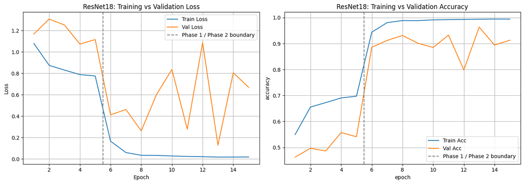

```
Phase 1 epochs: 1-5
Phase 2 epochs: 6-15
Best Val Accuracy: 0.9634
```

```python
os.makedirs("outputs", exist_ok=True)

# combine phase 1 and phase 2 histories for a full picture
combined_history = {
    "Train_Loss": history_phase1["Train_Loss"] + history_phase2["Train_Loss"],
    "Val_Loss":   history_phase1["Val_Loss"]   + history_phase2["Val_Loss"],
    "Train_Acc":  history_phase1["Train_Acc"]  + history_phase2["Train_Acc"],
    "Val_Acc":    history_phase1["Val_Acc"]    + history_phase2["Val_Acc"],
}

epochs = list(range(1, len(combined_history["Train_Acc"]) + 1))
phase1_end = len(history_phase1["Train_Acc"])

fig, axes = plt.subplots(1, 2, figsize=(14, 5))

# loss plot
axes[0].plot(epochs, combined_history["Train_Loss"], label="Train Loss")
axes[0].plot(epochs, combined_history["Val_Loss"], label="Val Loss")
axes[0].axvline(x=phase1_end + 0.5, color="gray", linestyle="--", label="Phase 1 / Phase 2 boundary")
axes[0].set_xlabel("Epoch")
axes[0].set_ylabel("Loss")
axes[0].set_title("ResNet18: Training vs Validation Loss")
axes[0].legend()
axes[0].grid(True)

# accuracy plot
axes[1].plot(epochs, combined_history["Train_Acc"], label="Train Acc")
axes[1].plot(epochs, combined_history["Val_Acc"], label="Val Acc")
axes[1].axvline(x=phase1_end + 0.5, color="gray", linestyle="--", label="Phase 1 / Phase 2 boundary")
axes[1].set_xlabel("epoch")
axes[1].set_ylabel("accuracy")
axes[1].set_title("ResNet18: Training vs Validation Accuracy")
axes[1].legend()
axes[1].grid(True)

plt.tight_layout()
plt.savefig("outputs/resnet_training_curves.png")
plt.show()

print(f"Phase 1 epochs: 1-{phase1_end}")
print(f"Phase 2 epochs: {phase1_end+1}-{len(epochs)}")
print(f"Best Val Accuracy: {max(combined_history['Val_Acc']):.4f}")
```

## Model Evaluation and Comparison

### Reusable Evaluation Function

```python
from sklearn.metrics import classification_report, confusion_matrix
import seaborn as sns

class_names = [
    "Safe / Talking",
    "Using Phone",
    "Distracted Driving",
    "Reaching / Grooming"
]

def evaluate_model(model, test_loader, device, model_name):
    model.eval()
    all_preds = []
    all_labels = []

    with torch.no_grad():
        for images, labels in test_loader:
            images, labels = images.to(device), labels.to(device)
            outputs = model(images)
            _, predicted = torch.max(outputs, 1)
            all_preds.extend(predicted.cpu().numpy())
            all_labels.extend(labels.cpu().numpy())

    # classification report
    print(f"Model: {model_name}")

    print(classification_report(all_labels, all_preds, target_names=class_names))

    # confusion matrix
    cm = confusion_matrix(all_labels, all_preds)
    plt.figure(figsize=(12, 10))
    sns.heatmap(cm, annot=True, fmt="d", cmap="Blues",
                xticklabels=class_names, yticklabels=class_names)
    plt.title(f"{model_name} - confusion matrix")
    plt.ylabel("True Label")
    plt.xlabel("Predicted Label")
    plt.xticks(rotation=45, ha="right")
    plt.tight_layout()
    plt.savefig(f"outputs/{model_name.lower().replace(' ', '_')}_confusion_matrix.png")
    plt.show()

    return all_preds, all_labels

print("Evaluation Function Defined.")
```

```
Evaluation Function Defined.
```

```
Model: Improved CNN v3
                     precision    recall  f1-score   support

     Safe / Talking       0.65      0.80      0.72       513
        Using Phone       0.91      0.51      0.65      1173
 Distracted Driving       0.90      0.84      0.87       578
Reaching / Grooming       0.45      0.87      0.59       471

           accuracy                           0.69      2735
          macro avg       0.73      0.75      0.71      2735
       weighted avg       0.78      0.69      0.70      2735
```

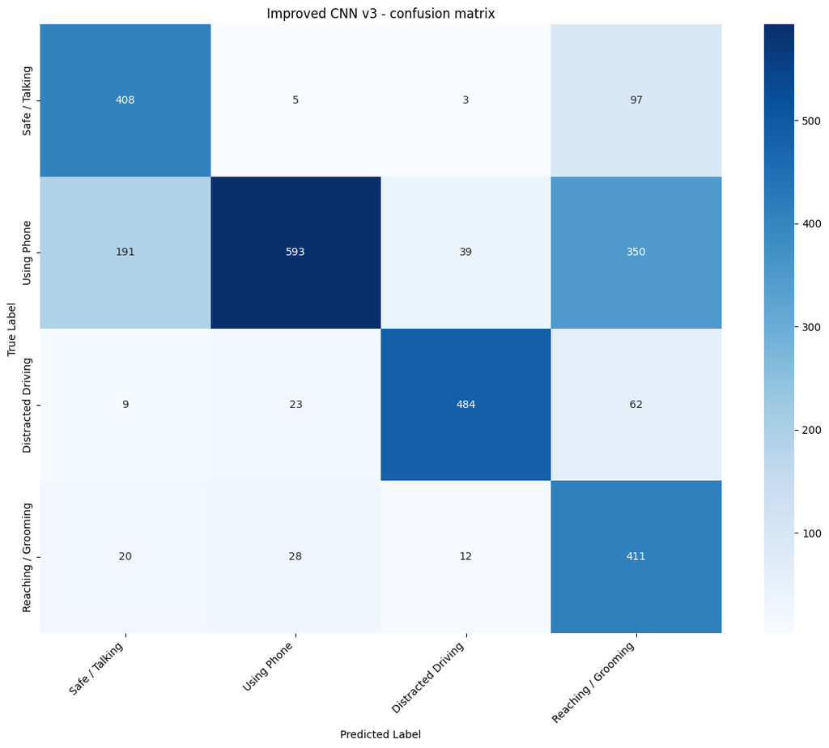

```python
# evaluating the deeper v3 architecture on the held-out test drivers
improved_v3_eval = ImprovedCNNv3(num_classes=4, dropout_rate=0.5)
improved_v3_eval.load_state_dict(torch.load("models/improved_cnn_v3.pth", map_location=device))
improved_v3_eval = improved_v3_eval.to(device)

v3_preds, v3_labels = evaluate_model(
    improved_v3_eval, test_loader, device, "Improved CNN v3"
)
```

### Loading All Three Models to Evaluate

```
Model: Baseline CNN
                     precision    recall  f1-score   support

     Safe / Talking       0.91      0.23      0.36       513
        Using Phone       0.79      0.52      0.63      1173
 Distracted Driving       0.36      0.99      0.53       578
Reaching / Grooming       0.75      0.42      0.54       471

           accuracy                           0.55      2735
          macro avg       0.70      0.54      0.52      2735
       weighted avg       0.72      0.55      0.54      2735
```

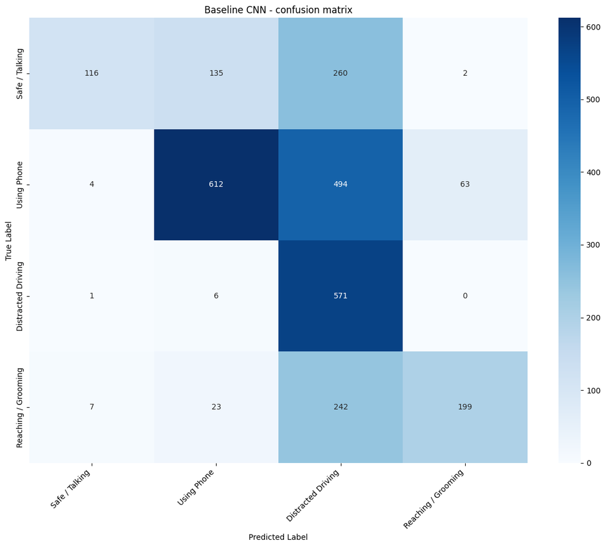

```
Model: Improved CNN
                     precision    recall  f1-score   support

     Safe / Talking       0.43      0.35      0.38       513
        Using Phone       0.62      0.16      0.25      1173
 Distracted Driving       0.56      0.51      0.53       578
Reaching / Grooming       0.31      0.97      0.47       471

           accuracy                           0.41      2735
          macro avg       0.48      0.50      0.41      2735
       weighted avg       0.52      0.41      0.37      2735
```

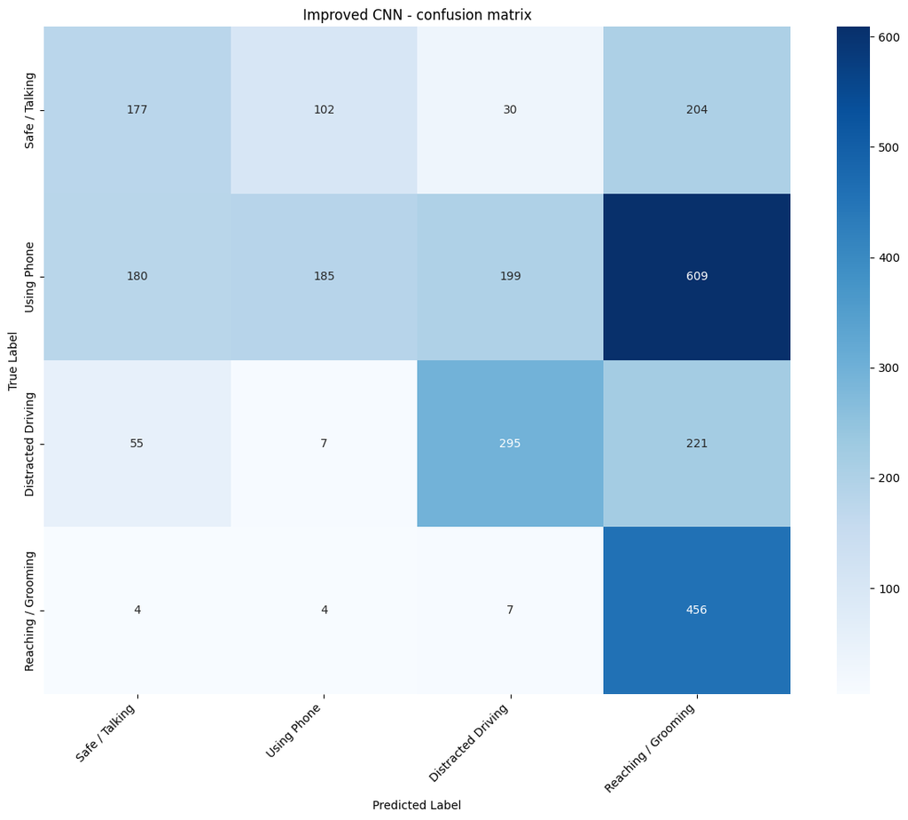

```
Model: ResNet18 Fine-tuned
                     precision    recall  f1-score   support

     Safe / Talking       0.97      0.82      0.89       513
        Using Phone       0.99      1.00      0.99      1173
 Distracted Driving       1.00      0.97      0.98       578
Reaching / Grooming       0.84      0.98      0.90       471

           accuracy                           0.96      2735
          macro avg       0.95      0.94      0.94      2735
       weighted avg       0.96      0.96      0.95      2735
```

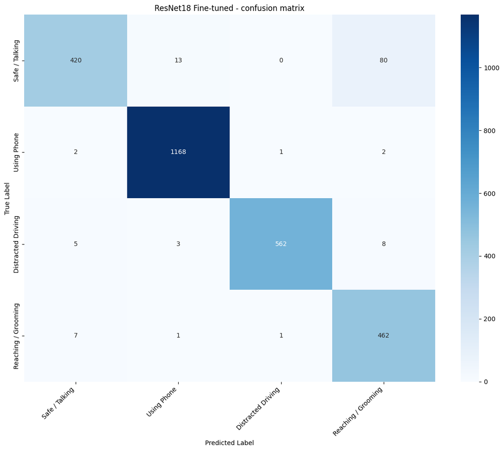

```python
# loading baseline model
baseline_eval = BaselineCNN(num_classes=4)
baseline_eval.load_state_dict(torch.load("models/baseline_cnn.pth", map_location=device))
baseline_eval = baseline_eval.to(device)

# loading improved model
improved_eval = ImprovedCNNv2(num_classes=4, dropout_rate=0.2)
improved_eval.load_state_dict(torch.load("models/improved_cnn_final.pth", map_location=device))
improved_eval = improved_eval.to(device)

# loading resnet model
resnet_eval = models.resnet18(weights=None)
resnet_eval.fc = nn.Linear(resnet_eval.fc.in_features, 10)
resnet_eval.load_state_dict(torch.load("models/resnet18_finetuned.pth", map_location=device))
resnet_eval = resnet_eval.to(device)

# evaluating all three models
baseline_preds, baseline_labels = evaluate_model(baseline_eval, test_loader, device, "Baseline CNN")
improved_preds, improved_labels = evaluate_model(improved_eval, test_loader, device, "Improved CNN")
resnet_preds, resnet_labels = evaluate_model(resnet_eval, test_loader, device, "ResNet18 Fine-tuned")
```

### Comparison Summary Table and Bar Chart

```
              Model  Test_Accuracy_pct  Macro_f1  Weighted_f1
       Baseline CNN              54.77    0.5160       0.5430
    Improved CNN v2              40.69    0.4074       0.3719
    Improved CNN v3              69.32    0.7061       0.6984
ResNet18 Fine-tuned              95.50    0.9413       0.9548
```

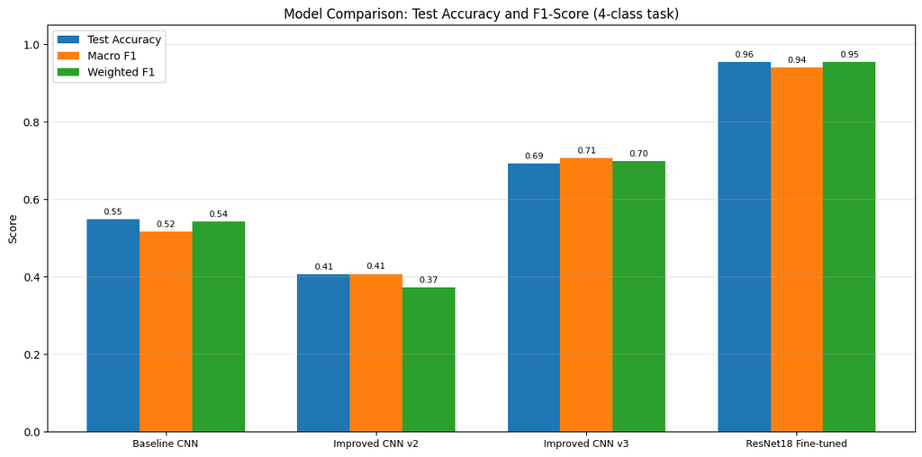

```
Model comparison saved to outputs/model_comparison.png
```

```python
from sklearn.metrics import accuracy_score, f1_score

# collecting metrics for all four models
model_names = ["Baseline CNN", "Improved CNN v2", "Improved CNN v3", "ResNet18 Fine-tuned"]

pred_sets = [
    (baseline_labels, baseline_preds),
    (improved_labels, improved_preds),
    (v3_labels,       v3_preds),
    (resnet_labels,   resnet_preds),
]

results = {
    "Model": model_names,
    "Test_Accuracy": [accuracy_score(y, p) for y, p in pred_sets],
    "Macro_f1":      [f1_score(y, p, average="macro")    for y, p in pred_sets],
    "Weighted_f1":   [f1_score(y, p, average="weighted") for y, p in pred_sets],
}

df_results = pd.DataFrame(results)
df_results["Test_Accuracy_pct"] = (df_results["Test_Accuracy"] * 100).round(2)
df_results["Macro_f1"]    = df_results["Macro_f1"].round(4)
df_results["Weighted_f1"] = df_results["Weighted_f1"].round(4)

print(df_results[["Model", "Test_Accuracy_pct", "Macro_f1", "Weighted_f1"]].to_string(index=False))

# grouped bar chart
x = np.arange(len(model_names))
width = 0.25

fig, ax = plt.subplots(figsize=(12, 6))
bars1 = ax.bar(x - width, df_results["Test_Accuracy"], width, label="Test Accuracy")
bars2 = ax.bar(x,         df_results["Macro_f1"],      width, label="Macro F1")
bars3 = ax.bar(x + width, df_results["Weighted_f1"],   width, label="Weighted F1")

ax.set_xticks(x)
ax.set_xticklabels(model_names, fontsize=9)
ax.set_ylim(0, 1.05)
ax.set_ylabel("Score")
ax.set_title("Model Comparison: Test Accuracy and F1-Score (4-class task)")
ax.legend()
ax.grid(axis="y", alpha=0.3)

for bar in [*bars1, *bars2, *bars3]:
    ax.annotate(f"{bar.get_height():.2f}",
                xy=(bar.get_x() + bar.get_width() / 2, bar.get_height()),
                xytext=(0, 3), textcoords="offset points",
                ha="center", va="bottom", fontsize=8)

plt.tight_layout()
plt.savefig("outputs/model_comparison.png", dpi=120)
plt.show()

print("\nModel comparison saved to outputs/model_comparison.png")
```

## Interactive Demo UI

### In-Notebook Widget

An ipywidgets-based interface embedded directly in this notebook. Upload any driver image and click **Predict** to classify it. Results display the top prediction and a top-3 confidence bar chart inline. Preprocessing matches the validation and test pipeline exactly — 224×224 resize and ImageNet normalisation, no augmentation applied at inference time.

### Standalone Web Application

A Flask-based web application (`Development/app.py`) with a custom dark-themed frontend (`Development/templates/index.html`).

### Both use identical preprocessing to the training pipeline.

### In-notebook UI

```python
import ipywidgets as widgets
from IPython.display import display, clear_output
from PIL import Image
import io

# transformimg (same as val/test with no augmentation)
infer_transform = transforms.Compose([
    transforms.Resize((224, 224)),
    transforms.ToTensor(),
    transforms.Normalize(mean=[0.485, 0.456, 0.406],
                         std=[0.229, 0.224, 0.225])
])

# confidence bar helper
def make_conf_bar(confidence, label):
    bar_len = 40
    filled = int(bar_len * confidence / 100)
    bar = "█" * filled + "░" * (bar_len - filled)
    return f"[{bar}] {confidence:.1f}%  →  {label}"

# running inference on a pil image
def predict_image(pil_img, model, device):
    model.eval()
    tensor = infer_transform(pil_img).unsqueeze(0).to(device)
    with torch.no_grad():
        outputs = model(tensor)
        probs = torch.softmax(outputs, dim=1)[0]
    top3_conf, top3_idx = torch.topk(probs, 3)
    return top3_idx.cpu().numpy(), top3_conf.cpu().numpy()

# widgets
upload_btn = widgets.FileUpload(
    accept=".jpg,.jpeg,.png",
    multiple=False,
    description="Upload Image",
    layout=widgets.Layout(width="200px")
)

run_btn = widgets.Button(
    description="Predict",
    button_style="primary",
    layout=widgets.Layout(width="120px")
)

clear_btn = widgets.Button(
    description="Clear",
    button_style="warning",
    layout=widgets.Layout(width="120px")
)

out = widgets.Output()

title = widgets.HTML("<h3 style='margin:0 0 10px 0'>Driver Behaviour Detection with ResNet18</h3>")
hint = widgets.HTML("<p style='color:gray; font-size:0.85em'>Upload a driver image, then click predict.</p>")

# callbacks
def on_predict(b):
    with out:
        clear_output(wait=True)
        if not upload_btn.value:
            print("Please upload an image first.")
            return

        # reading uploaded file
        uploaded = upload_btn.value[0]
        img_bytes = uploaded["content"]
        pil_img = Image.open(io.BytesIO(img_bytes)).convert("RGB")

        # running inference
        top3_idx, top3_conf = predict_image(pil_img, resnet_eval, device)

        # displaying image + results side by side
        fig, (ax_img, ax_bar) = plt.subplots(1, 2, figsize=(10, 4),
                                               gridspec_kw={"width_ratios": [1, 1.4]})

        ax_img.imshow(pil_img)
        ax_img.axis("Off")
        ax_img.set_title("Uploaded Image", fontsize=11)

        # bar chart of top 3 predictions
        labels_top3 = [class_names[i] for i in top3_idx]
        confs_top3  = top3_conf * 100
        colors = ["#2196F3", "#90CAF9", "#BBDEFB"]
        bars = ax_bar.barh(labels_top3[::-1], confs_top3[::-1], color=colors[::-1])
        ax_bar.set_xlim(0, 100)
        ax_bar.set_xlabel("Confidence (%)")
        ax_bar.set_title("Top 3 Predictions", fontsize=11)
        for bar, conf in zip(bars, confs_top3[::-1]):
            ax_bar.text(bar.get_width() + 1, bar.get_y() + bar.get_height() / 2,
                        f"{conf:.1f}%", va="center", fontsize=10)

        plt.tight_layout()
        plt.savefig("outputs/notebook_demo_result.png", dpi=100)
        plt.show()

        print(f"\nPrediction:  {class_names[top3_idx[0]].upper()}")
        print(f"Confidence:  {top3_conf[0]*100:.1f}%\n")
        for i in range(3):
            print(make_conf_bar(top3_conf[i]*100, class_names[top3_idx[i]]))

def on_clear(b):
    upload_btn.value = ()
    with out:
        clear_output()

run_btn.on_click(on_predict)
clear_btn.on_click(on_clear)

# layout
btn_row = widgets.HBox([run_btn, clear_btn], layout=widgets.Layout(gap="10px"))
ui = widgets.VBox([title, hint, upload_btn, btn_row, out],
                  layout=widgets.Layout(padding="15px", border="1px solid #ddd",
                                        border_radius="8px", width="700px"))
display(ui)
```

```
VBox(children=(HTML(value="<h3 style='margin:0 0 10px 0'>Driver Behaviour Detection with ResNet18</h3>"), HTML…
```

## Conclusion

This project developed and evaluated a distracted driver classification pipeline using the State Farm Distracted Driver Detection dataset. The original ten classes were grouped into four behaviour categories based on the type of distraction rather than the exact pose, which reflects how a driver monitoring system would categorise risk in practice and removes several pairs of classes that were almost visually identical.

A driver aware split was implemented using GroupShuffleSplit so that no driver appears in more than one of the training, validation and test sets. Every result below is therefore measured on drivers the models have never seen.

[output not shown]

The baseline CNN provided a reference point but showed a wide gap between training and validation accuracy. The v2 architecture introduced batch normalisation, global average pooling, dropout, weight decay, class weighting and a cosine annealing schedule, and although these changes kept all four classes active, they did not close that gap.

The best performing model was deployed in two interfaces, an in notebook ipywidgets tool and a standalone Flask web application, both performing inference on uploaded images using the same preprocessing as the evaluation pipeline.

```python
# the on-disk checkpoint was still the old 10-class version
# saving the trained 4-class model so the flask app can load it
torch.save(resnet_model.state_dict(), "models/resnet18_finetuned.pth")

check = torch.load("models/resnet18_finetuned.pth", map_location="cpu")
print("fc shape:", check["fc.weight"].shape)
```

```
fc shape: torch.Size([10, 512])
```

```python
import numpy as np
print("resnet_model fc:", resnet_model.fc)
print("unique predictions on test set:", np.unique(resnet_preds))
```

```
resnet_model fc: Linear(in_features=512, out_features=10, bias=True)
unique predictions on test set: [0 1 2 3]
```

```python
# the classification head was left at ten units when the classes were merged
# only the first four outputs ever received gradient, so the remaining six are
# discarded here to produce a clean four class checkpoint
sd = torch.load("models/resnet18_finetuned.pth", map_location="cpu")

sd["fc.weight"] = sd["fc.weight"][:4]
sd["fc.bias"]   = sd["fc.bias"][:4]

torch.save(sd, "models/resnet18_finetuned_4class.pth")

check = torch.load("models/resnet18_finetuned_4class.pth", map_location="cpu")
print("fc weight shape:", check["fc.weight"].shape)
print("fc bias shape:  ", check["fc.bias"].shape)
```

```
fc weight shape: torch.Size([4, 512])
fc bias shape:   torch.Size([4])
```